**Secretaría del Bienestar para la Comunidad**Presidencia Municipal de Mineral de la Reforma, Hidalgo

3ª edición · Día de Muertos 2026

# Festival Chicomecóatl

Programa de actividades y apoyo de cada secretaría. Más abajo elige tu secretaría y verás solo lo que te toca, día por día.

**Fechas**

27 oct al 2 nov

**Sedes**

La Calera, CEMART, Pachuquilla y panteones

**Vestimenta**

Alusiva a las festividades

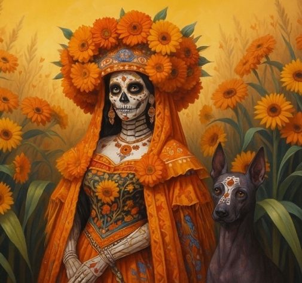

Chicomecóatl y Sintli, embajadores del festival

## 1¿De qué secretaría eres?

Toca el nombre de tu área. La página te mostrará solo tus actividades y lo que te toca hacer cada día. Puedes cambiarla cuando quieras.

## Recorridos

Rutas de los contingentes. Seguridad Ciudadana coordina el cierre de calles y el apoyo vial; toca un mapa para verlo en grande.

[figure not shown]

### Rodada ciclista y Procesión de las Ánimas

Concentración 17:00 hSalida 18:00 hDuración aprox. 1 h

[figure not shown]

### Desfile de Día de Muertos

Lunes 2 de noviembre. A pie desde la entrada de Pachuquilla, a la altura de la gasera, hasta el frente del auditorio; pasa por la explanada principal a las 19:00 h.

Concentración 17:30 hSalida 18:30 hDuración aprox. 30 min

## Indicaciones para todas las secretarías

Aplican a todo el personal que participa en el festival, además de las tareas de cada día.

### Descarga de la flor y armado de ramos

1

**Martes 27 de octubre, 9:00 h**Descarga de la flor

2

**Sábado 31 de octubre, 9:00 h**Armado de ramos

### Personal de apoyo

- Con toda la disposición y actitud de servicio.
- Vigilancia de actividades y apoyo en asuntos generales.
- Recibir indicaciones con Andrés Vaca, “El Mago”: 771 204 7150.

### Secretaría del Despacho (Imagen)

- Designar personal para foto y video del evento.
- Foto y video del presidente municipal y la presidenta del DIF en los eventos donde asistan.
- Diseño e impresión del material de difusión.